# Make Matchups

B Steele, Colorado State University, ROSSyndicate

last updated Sept 10, 2026

This code creates matchups between the AquaMatch SDD files and the siteSR files. We use a generous 5-day window to work from for future steps. Because we complete some RANSAC-style filtering in this script, we do reduce the AOI to the HUC02’s we care about for the regional model.

## Setup

```r
# load libraries
library(igraph)
library(AquaMatchr) # if install needed: remotes::install_github(repo = "AquaSat/AquaMatchr")
library(data.table)
library(arrow)
library(sf)
library(tmap)
library(tigris)
library(tidyverse)
```

```r
# login to EDI - this is a work around for error popping up in AquaMatchr
# requires EDIutils, which is required by AquaMatchr so no need to import
EDIutils::login(key = Sys.getenv('EDI_API_key'))
```

```
## Logged in with EDI-API key.
```

## AquaMatch data

Download AquaMatch as necessary.

```r
# note location for file storage when downloading via AquaMatchr
aquamatch_dir <- "aquamatch_files"
dir.create(aquamatch_dir)
```

IMPORTANT: the chunk below must be run interactively in the R console at least once (not via Knit) before this doc is knit. AquaMatchr’s downloader functions can prompt interactively (readline) to confirm overwriting existing files, and knitting is non-interactive, so it hangs forever waiting for an answer no one can give. Running it in the console first lets you answer any prompt and populate the cache; once the cache files below exist, knitting will just read from them and skip the network calls.

```r
# download_parameters() doesn't cache to disk, so we cache it ourselves -
# otherwise every knit re-downloads from EDI
sdd_cache <- file.path(aquamatch_dir, "sdd_newest.feather")
if (!file.exists(sdd_cache)) {
  # use AquaMatchr for data gathering
  sdd <- download_parameters("sdd", "newest")
  # get it out of a list
  sdd <- sdd[[1]]
  write_feather(sdd, sdd_cache)
  rm(sdd)
}

# apply some QAQC filters for higher quality data and ransac filter
sdd_filtered <- file.path(aquamatch_dir, "sdd_quality_filter.feather")

# run a ransac-like algorithm per site to remove outliers
ransac_site <- function(date, sdd,
                        n_iter = 50,
                        mad_thresh = 2,
                        n_sd = 3,
                        range_buffer_frac = 0.15,
                        min_diff = 1,
                        min_sample = 8,
                        vote_frac = 0.6) {
  n <- length(sdd)
  if (n < min_sample + 1) return(rep(NA, n))  # too few points to run ransac

  t <- as.numeric(date)
  # tally, per point, how many valid iterations called it an inlier
  inlier_votes <- rep(0L, n)
  n_valid_iter <- 0L

  for (i in 1:n_iter) {
    idx <- sample(n, min_sample)
    if (length(unique(t[idx])) < 2) next  # avoid degenerate fit (same date)
    out_idx <- setdiff(seq_len(n), idx)

    fit <- lm(sdd[idx] ~ t[idx])
    pred <- coef(fit)[1] + coef(fit)[2] * t
    resid <- sdd - pred
    # scale should come from held-out points only - points used to fit the
    # line have near-zero residual by construction, so including them
    # deflates the scale (and threshold) whenever min_sample is close to n,
    # making a single held-out point look like an outlier over a trivial
    # difference. use MAD rather than sd() here: sd() is itself inflated by
    # a cluster of genuine outliers landing in the held-out set (a handful of
    # large same-direction residuals drag the mean and blow up the squared
    # deviations), which loosens the threshold and lets that same cluster
    # vote itself in as inliers. MAD is robust to that as long as the
    # cluster is a minority of the held-out set, since it centers on the
    # median rather than the mean.
    resid_scale <- if (length(out_idx) >= 2) {
      mad(resid[out_idx], constant = mad_thresh, na.rm = TRUE)
    } else {
      # too few held-out points (n == min_sample + 1) to trust their own MAD -
      # fall back to all-points MAD (deflated, but not degenerate) instead
      mad(resid, constant = mad_thresh, na.rm = TRUE)
    }
    # never flag a point closer than min_diff to the fit line, regardless of
    # how tight the scale-based threshold is - a < 1 m disagreement isn't
    # meaningfully an outlier for Secchi depth.
    threshold <- max(n_sd * resid_scale, min_diff, na.rm = TRUE)
    inliers <- !is.na(resid) & abs(resid) < threshold

    inlier_votes <- inlier_votes + as.integer(inliers)
    n_valid_iter <- n_valid_iter + 1L
  }

  # indicate when no iteration ever produced a usable fit
  if (n_valid_iter == 0) return(rep(NA, n))

  # a point is an inlier if at least vote_frac of the valid iterations agreed
  best_inliers <- (inlier_votes / n_valid_iter) >= vote_frac

  # a flagged point can't be implausible for this site if its value falls
  # within the range other accepted (inlier) observations already span here -
  # deviating from the local trend line isn't grounds to flag it when the
  # site itself has already produced values in that range. this matters most
  # for low-n sites, where a short fit sample leaves little room to
  # distinguish a real trend from a value the site has simply shown before
  if (any(best_inliers)) {
    inlier_range <- range(sdd[best_inliers], na.rm = TRUE)
    # scale the buffer to this site's typical SDD rather than using a flat
    # meters value - 0.5 m is a huge margin at a 1 m-visibility site and
    # negligible at a 10 m-visibility site
    range_buffer <- range_buffer_frac * mean(sdd[best_inliers], na.rm = TRUE)
    best_inliers <- best_inliers | (sdd >= inlier_range[1] + range_buffer &
                                      sdd <= inlier_range[2] - range_buffer)
  }

  best_inliers
}


if (!file.exists(sdd_filtered)) {
  set.seed(43)
  read_feather(sdd_cache) %>%
    filter(
      # do some SDD filters - must be in higher tiers of data
      tier < 3,
      # must have a reasonable  value
      harmonized_value >= 0.1,
      # if there are aggregated rows, they generally agree
      harmonized_value_cv <= 0.25 | is.na(harmonized_value_cv),
      # no flags
      misc_flag == 0,
      # not a bottom hit
      depth_flag == 0,
      # and we'll just grab lake/res/impoundment data
      ResolvedMonitoringLocationTypeName == "Lake, Reservoir, Impoundment"
    ) %>%
    group_by(MonitoringLocationIdentifier) %>%
    arrange(harmonized_local_time) %>%
    mutate(is_inlier = ransac_site(harmonized_local_time, harmonized_value)) %>%
    ungroup() %>%
    # also reverse the flag in cases where multiple measurements are made
    mutate(is_inlier = if_else(harmonized_row_count > 1 &
                                 (!is_inlier | is.na(is_inlier)),
                               TRUE,
                               is_inlier)) %>%
    write_feather(sdd_filtered)
}
```

Check whether flagging concentrates at the SDD extremes rather than spreading evenly across the distribution. A high-end concentration here isn’t necessarily a problem here: we expect a lot of what lands in the far right tail of raw SDD is genuinely implausible (deeper than the water body, deeper than the instrument’s rope, transcription errors, etc.) rather than real high-clarity variability - the point of this check is to tell those two cases apart before trusting the filter.

```r
sdd_ransac_check <- read_feather(sdd_filtered)
```

Let’s look at highly-flagged sites as a spot-check.

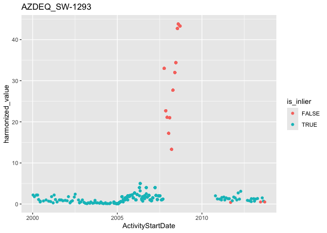

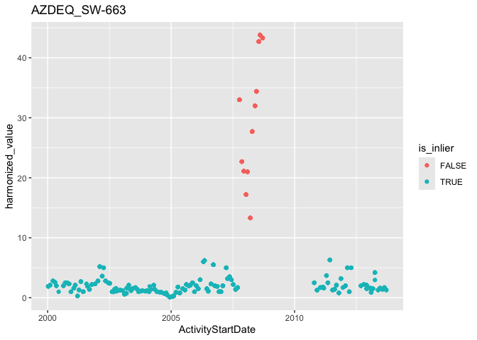

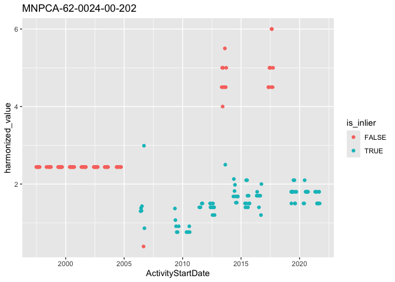

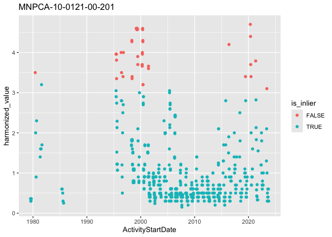

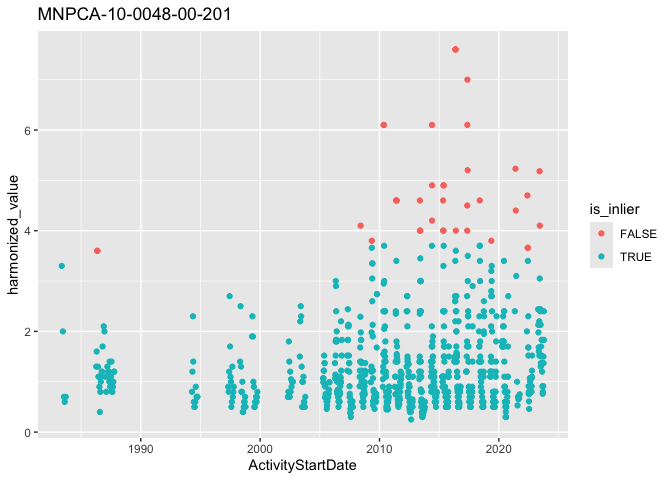

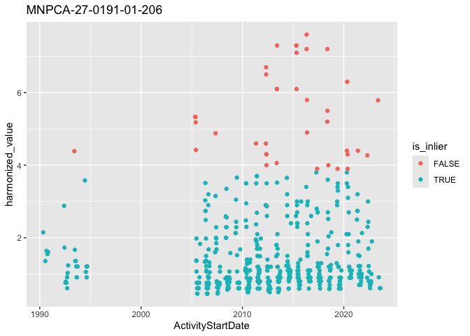

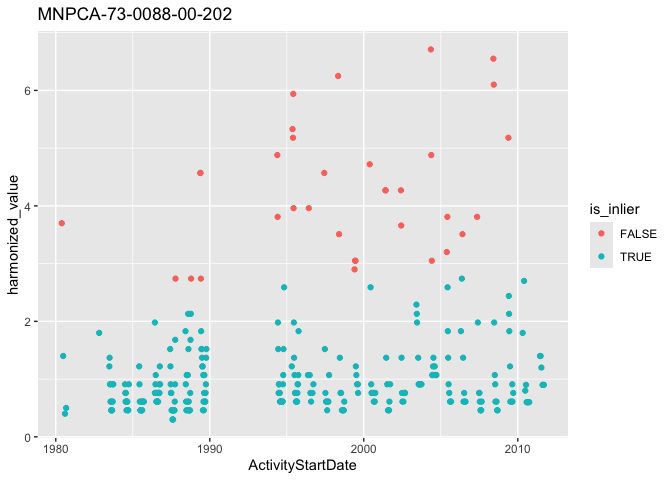

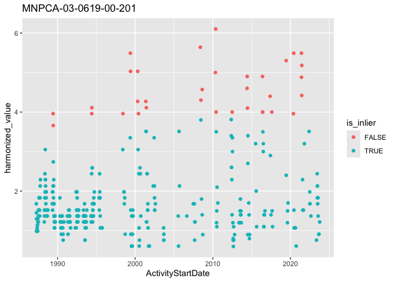

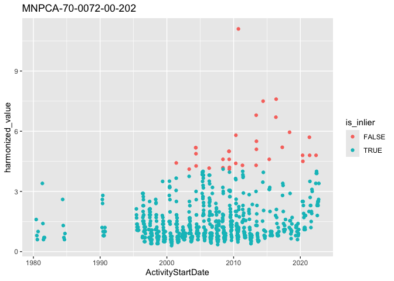

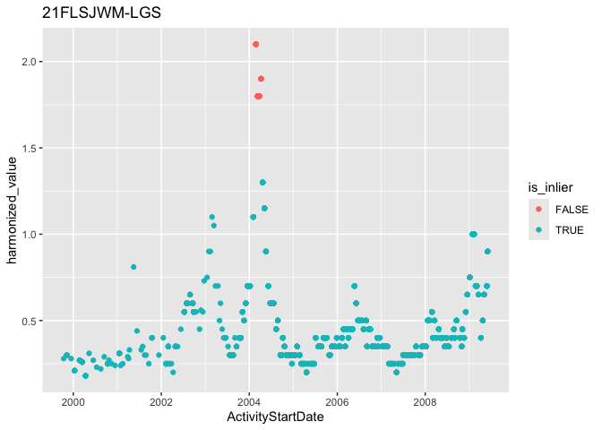

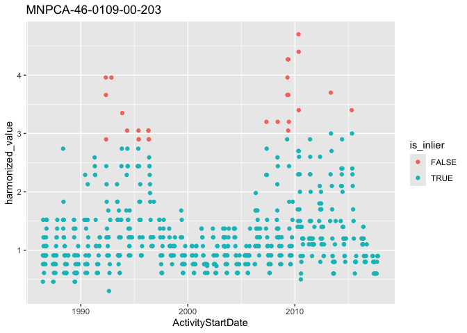

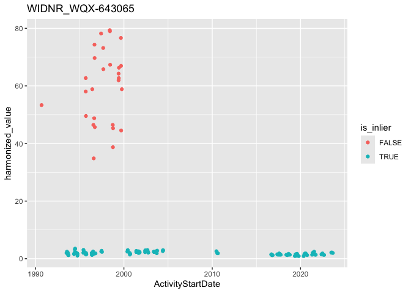

[28 more figures not shown]

```r
high_flag_sites <- sdd_ransac_check %>%
  summarize(n = n(),
            n_flagged = sum(is_inlier == FALSE),
            mean_sdd = mean(harmonized_value),
            .by = c(MonitoringLocationIdentifier, lat, lon)) %>%
  arrange(-n_flagged) %>%
  filter(n_flagged >= 20)

map(.x = high_flag_sites$MonitoringLocationIdentifier,
    ~ sdd_ransac_check %>%
      filter(MonitoringLocationIdentifier == .x) %>%
      ggplot(., aes(x = ActivityStartDate,
                    y = harmonized_value,
                    color = is_inlier)) +
      geom_point() +
      labs(title = .x))
```

There are clearly some over and under flagging examples here, but it’s a bit out of scope to refine the ransac futher.

```r
sdd_ransac_check <- sdd_ransac_check %>%
  mutate(is_inlier = case_when(MonitoringLocationIdentifier == "AZDEQ_SW-1293" &
                                 harmonized_value > 10 ~ FALSE,
                               MonitoringLocationIdentifier == "MNPCA-62-0024-00-202" &
                                 ActivityStartDate < ymd("2005-01-01") ~ FALSE,
                               MonitoringLocationIdentifier == "WIDNR_WQX-643065" &
                                 harmonized_value > 20 ~ FALSE,
                               .default = is_inlier))

write_feather(sdd_ransac_check, sdd_filtered)
```

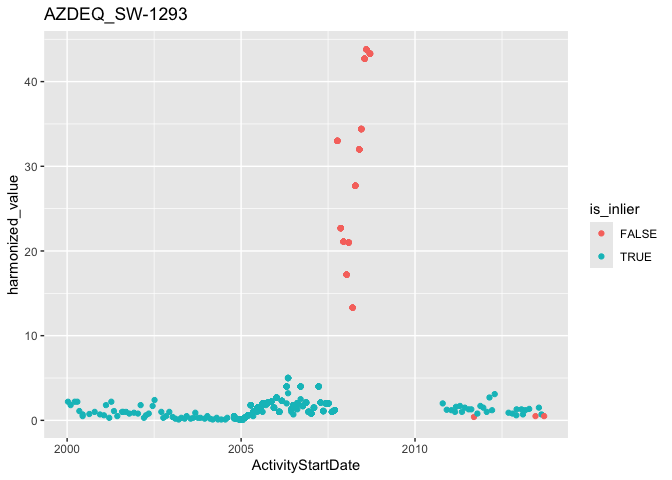

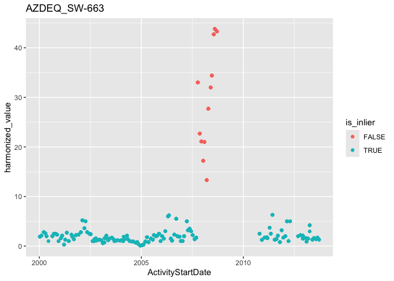

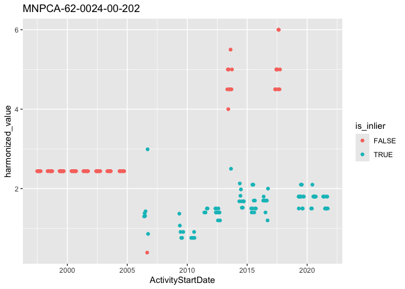

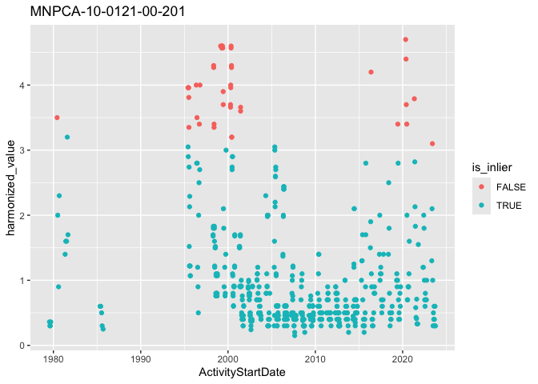

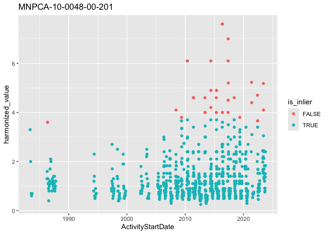

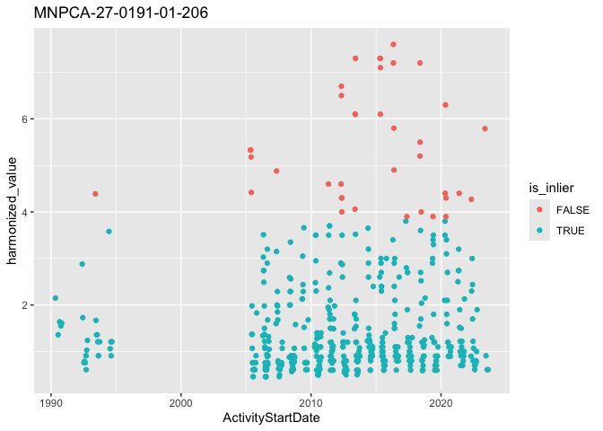

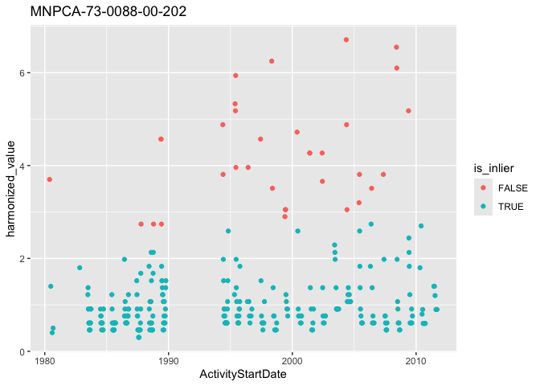

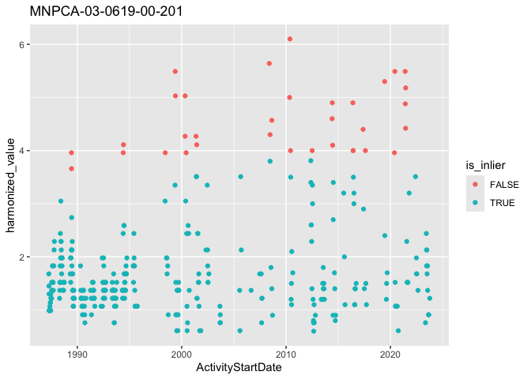

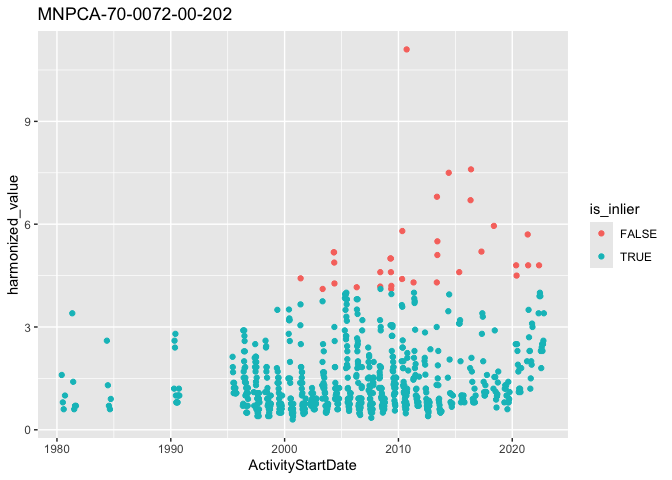

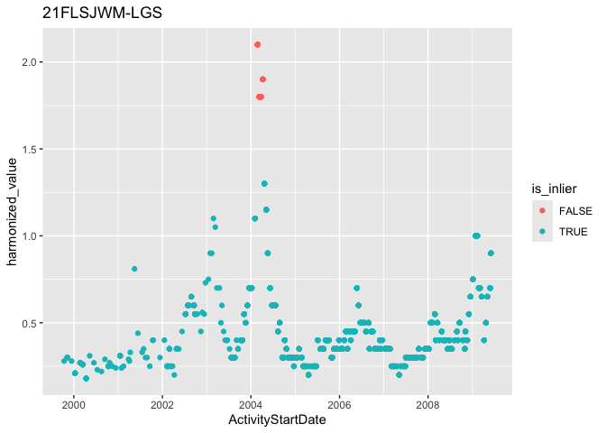

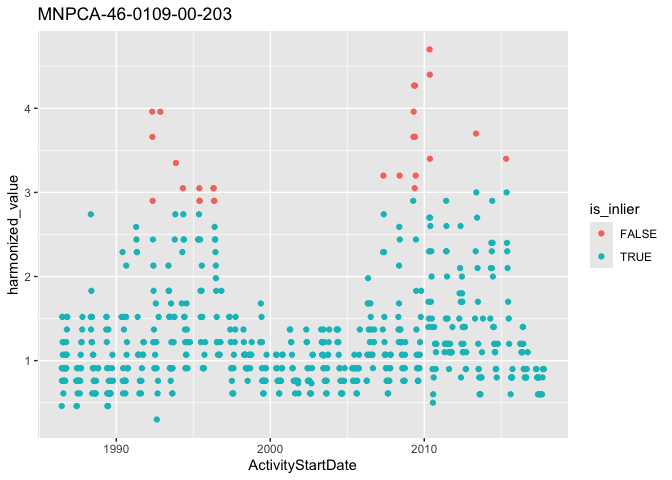

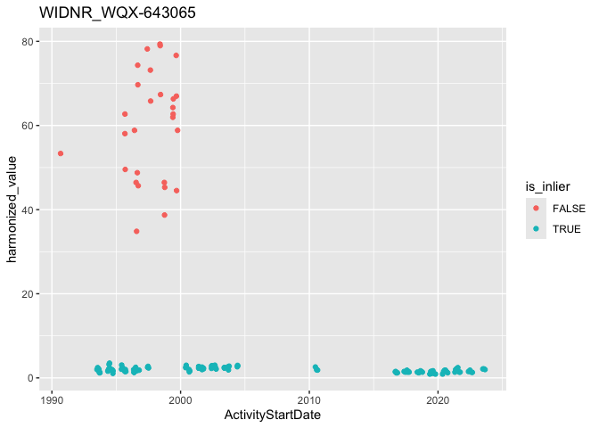

[28 more figures not shown]

```r
high_flag_sites <- sdd_ransac_check %>%
  summarize(n = n(),
            n_flagged = sum(is_inlier == FALSE),
            mean_sdd = mean(harmonized_value),
            .by = c(MonitoringLocationIdentifier, lat, lon)) %>%
  arrange(-n_flagged) %>%
  filter(n_flagged >= 20)

map(.x = high_flag_sites$MonitoringLocationIdentifier,
    ~ sdd_ransac_check %>%
      filter(MonitoringLocationIdentifier == .x) %>%
      ggplot(., aes(x = ActivityStartDate,
                    y = harmonized_value,
                    color = is_inlier)) +
      geom_point() +
      labs(title = .x))
```

Let’s also look to see what fraction of observations are indicated to be outliers:

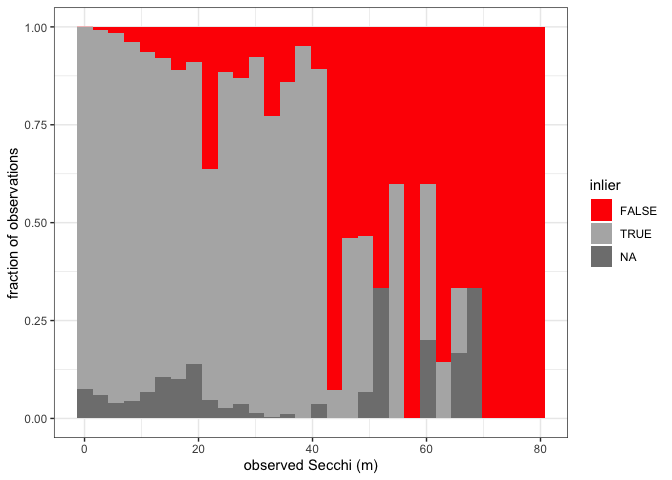

```r
ggplot(sdd_ransac_check, aes(x = harmonized_value, fill = is_inlier)) +
  geom_histogram(position = "fill", bins = 30) +
  scale_fill_manual(values = c(`TRUE` = "grey70", `FALSE` = "red")) +
  labs(x = "observed Secchi (m)", y = "fraction of observations",
       fill = "inlier") +
  theme_bw()
```

This all looks okay.

And now download (or load) siteSR data.

```r
# download_siteSR() writes files to aquamatch_dir, and if it finds files
# already there it prompts interactively (readline) to confirm overwrite -
# that prompt is what hangs the knit, since there's no console to answer it.
# so, check for existing files first and only download if they're missing
siteSR_existing <- list.files(
  aquamatch_dir,
  pattern = "siteSR_Landsat.*DSWE1_.*\\.feather$|sites_with_NHD_info.*\\.csv$|lakeSR_collated_handoffs.*\\.csv$",
  full.names = TRUE
)

if (length(siteSR_existing) > 0) {
  siteSR <- siteSR_existing
} else {
  siteSR <- download_siteSR(save_location = aquamatch_dir)
}

# stack the SR product
unified_data <- file.path(aquamatch_dir, "siteSR_DSWE1_full_concatenation.feather")
if (!file.exists(unified_data)) {
  # stack SR product
  file_list <- siteSR[grepl(".feather", siteSR)]

  # Read files and stack - pulled from AquaMatchr buildSR() function
  # We use the {arrow} package to concatenate the datasets into a single table
  # instead of something like rbind(), which likely will use more memory than is
  # available to the user.
  unified_sr_dataset <- open_dataset(
    # All files indicated to contain SR data
    sources = file_list,
    # The files should not be assumed to have Hive-style partitioning
    hive_style = FALSE,
    # They are saved as .feather files
    format = "feather",
    # Don't assume all files in the file_list have the same scheme. For
    # example, Aerosols cols may not be present in all
    unify_schemas = TRUE
  ) %>%
    # Convert to Arrow Table
    as_arrow_table()

  write_feather(unified_sr_dataset,
                file.path(aquamatch_dir,
                          "siteSR_DSWE1_full_concatenation.feather"))

  # remove the dataset from workingspace
  rm(unified_sr_dataset)
}
```

Scene-level metadata (cloud cover, image quality, geometric accuracy, etc.) isn’t carried through siteSR’s per-site aggregation, so we download it separately and join it on below via `sat_id`.

```r
source("regional_clarity/R/download_sceneMetadata.R")

# same interactive-overwrite-hang workaround as download-siteSR above
scene_metadata_existing <- list.files(
  aquamatch_dir,
  pattern = "sceneMetadata_Landsat(457|89)\\.csv$",
  full.names = TRUE
)
if (length(scene_metadata_existing) > 0) {
  scene_metadata_paths <- scene_metadata_existing
} else {
  scene_metadata_paths <- download_sceneMetadata(save_location = aquamatch_dir, product = "siteSR")
}

# LS457 and LS89 have slightly different columns (e.g. a single
# IMAGE_QUALITY vs. split IMAGE_QUALITY_OLI/_TIRS), so bind_rows() unions
# them rather than assuming identical schemas
scene_metadata <- map(scene_metadata_paths, read_csv, show_col_types = FALSE) %>%
  bind_rows() %>%
  filter(CLOUD_COVER < 20)
```

We’ll also do some site filtering - sites that are very close to shore and may have contamination should be removed from training.

```r
sites <- read_csv("aquamatch_files/siteSR_collated_WQP_NWIS_sites_with_NHD_info_2025-06-04.csv") %>%
  filter(flag_optical_shoreline == 0,
         number_int_wb == 1,
         (flag_thermal_TM_shoreline == 0 |
            flag_thermal_ETM_shoreline == 0 |
            flag_thermal_TIRS_shoreline == 0)) %>%
  select(siteSR_id, wb_nhd_id, wb_gnis_name, wb_areasqkm,
         flag_thermal_TM_shoreline, flag_thermal_ETM_shoreline,
         flag_thermal_TIRS_shoreline, WGS84_Latitude, WGS84_Longitude)
```

Different `siteSR_id` values (different source prefixes - `WQP_*`, `AM_*`, `NWIS_*`, etc.) can still be the exact same physical monitoring location, or two locations close enough together that Landsat can’t tell them apart. Two sites within 100m of each other but assigned to *different* waterbodies aren’t the same location - that’s more likely two real, distinct water features close together (or an NHD assignment error) than one site measured twice - so sites are only collapsed together when they’re both within 100m of each other *and* share the same `wb_nhd_id`. Grouping is transitive (connected components over that adjacency), so a chain of near-duplicates collapses into a single `location_id` even if its two most-distant members are themselves more than 100m apart.

```r
site_pts <- sites %>%
  st_as_sf(coords = c("WGS84_Longitude", "WGS84_Latitude"), crs = 4326,
           remove = FALSE)

# sparse adjacency: which sites (including itself) fall within 100m of
# each site
site_within_100m <- st_is_within_distance(site_pts, dist = 100)

# ...then restrict those pairs to ones sharing a waterbody - equality is
# symmetric, so this keeps the adjacency symmetric (if j survives in i's
# filtered neighbor list, i survives in j's) for the connected-components
# step below
wb_nhd_id <- sites$wb_nhd_id
site_within_100m_same_wb <- Map(
  function(nbrs, wb) nbrs[wb_nhd_id[nbrs] == wb],
  site_within_100m, wb_nhd_id
)

# connected components over that adjacency - this is what makes the
# grouping transitive rather than strictly pairwise
site_components <- components(
  graph_from_adj_list(site_within_100m_same_wb, mode = "all")
)$membership

pad <- nchar(as.character(max(site_components)))
sites <- sites %>%
  mutate(location_id = sprintf(paste0("loc_%0", pad, "d"), site_components))

# one row per de-duplicated location, listing the individual siteSR_id
# values collapsed into it
site_location_groups <- sites %>%
  summarize(n_sites = n(),
            siteSR_ids = list(siteSR_id),
            WGS84_Latitude = mean(WGS84_Latitude),
            WGS84_Longitude = mean(WGS84_Longitude),
            .by = location_id) %>%
  arrange(-n_sites)

print(paste0(nrow(site_location_groups %>% filter(n_sites >1)), " locations have more than one site in the 100m area"))
```

```
## [1] "7711 locations have more than one site in the 100m area"
```

```r
site_location_groups %>%
  filter(n_sites > 20)
```

```
## # A tibble: 21 × 5
##    location_id n_sites siteSR_ids WGS84_Latitude WGS84_Longitude
##    <chr>         <int> <list>              <dbl>           <dbl>
##  1 loc_04689        86 <chr [86]>           37.0          -111.
##  2 loc_01778        70 <chr [70]>           46.8           -92.1
##  3 loc_04739        50 <chr [50]>           36.0          -115.
##  4 loc_04747        42 <chr [42]>           36.1          -115.
##  5 loc_04762        42 <chr [42]>           36.2          -115.
##  6 loc_04764        42 <chr [42]>           36.1          -114.
##  7 loc_10975        41 <chr [41]>           43.2           -86.3
##  8 loc_06218        32 <chr [32]>           38.7          -119.
##  9 loc_19907        32 <chr [32]>           45.5           -89.0
## 10 loc_19861        29 <chr [29]>           43.5           -97.0
## # ℹ 11 more rows
```

## Filter reflectance outliers before matching

- **Regional pre-filter**: restrict to the 7 HUC2 basins that actually appear anywhere in this project’s final 6-state regional output. This is a coarse, safe, purely columnar filter - nothing outside these HUC2s can reach the final output regardless, since the precise spatial HUC4 boundary filter still runs unchanged, later, in `02_subset_to_region.Rmd`. It’s a compute-scoping choice for *this* corpus, not a requirement of the method below, which is per-site and self-contained - a future refresh, or a different application of the same filter (e.g. to a different reservoir set), would define its own cheap scope rather than reusing this HUC2 list.
- **Metadata QA**: `pCount_dswe1/pCount_dswe_gt0 > 0.5`, `pCount_dswe1 > 8`, `prop_clouds == 0` pretty generous filters to remove possbile contamination
- **Scene-level cloud QA**: `sat_id` is further restricted to scenes in `scene_metadata` with `CLOUD_COVER < 20`, catching a partly-cloudy scene that could have aerosol impacts on the temp and optical data
- **Site geometry QA**: `siteSR_id` is restricted to the `sites` table built above, which drops near-shore sites (`flag_optical_shoreline`, thermal shoreline flags) and sites spanning more than one waterbody (`number_int_wb == 1`) - a contaminated or ambiguous site shouldn’t feed its own line fit either.
- **Site de-duping**: The `location_id` dedup built alongside it (collapsing same-waterbody sites within 100m) is used to identify one representative site for the RANSAC-like filter.

The filter itself (`ransac_site_multiband()`) is the same per-site, random-subsample RANSAC-like approach as `ransac_site()` above, just fitting all seven corrected channels (six reflectance bands plus surface temperature) per iteration instead of one, standardized by each channel’s own MAD-based scale from a single all-data fit: reflectance is a shakier fit against a straight line over a site’s full record than SDD is (blooms, turbidity, and seasonality move bands around much more), so instead of a raw residual threshold in reflectance units we standardize each band’s per-iteration residual by its own MAD and combine into one z-score per point, then threshold on that combined score.

The regression inside the iteration loop is written as closed-form OLS rather than `lm()` to reduce processing time and we parallellize to further optimize the time need here.

```r
siteSR_regional_filtered <- file.path(aquamatch_dir, "siteSR_DSWE1_regional_band_filtered.feather")
# a second, diagnostics-only cache: siteSR_regional_filtered only keeps
# inlier rows and drops is_band_inlier, so the checks below (which need to
# see flagged points too) reload from here instead - written once alongside
# siteSR_regional_filtered, then read back unconditionally further down so
# it renders on every knit without re-running the RANSAC fit
siteSR_regional_corr_diag <- file.path(aquamatch_dir, "siteSR_DSWE1_regional_band_ransac_diagnostics.feather")

if (any(!file.exists(c(siteSR_regional_filtered, siteSR_regional_corr_diag)))) {

  # HUC2 basins that appear anywhere in this project's final regional output
  regional_huc2 <- c(10, 11, 13, 14, 15, 16, 17)

  # add some QA filters
  siteSR_regional_raw <- open_dataset(unified_data, format = "feather") %>%
    filter(huc2 %in% regional_huc2,
           pCount_dswe1 / pCount_dswe_gt0 > 0.5,
           pCount_dswe1 > 8,
           prop_clouds == 0,
           # filter for scenes with < 20% cloud cover
           sat_id %in% scene_metadata$sat_id) %>%
    collect()

  # for locations with more than one siteSR_id within 100m (see
  # site_location_groups above), keep just the first siteSR_id per
  # location_id, so a duplicated physical site doesn't feed the filter below
  # more than once
  representative_sites <- sites %>%
    distinct(location_id, .keep_all = TRUE) %>%
    pull(siteSR_id)

  siteSR_regional_dedup <- siteSR_regional_raw %>%
    filter(siteSR_id %in% representative_sites)

  # apply the same Gardner et al. cross-sensor correction as script 04's
  # sensor-corrections chunk, so the filter below judges harmonized bands
  am_corr_LS7 <- read_csv(file.path(aquamatch_dir, "lakeSR_collated_handoffs_GEEv2025-02-12_QAv2025-06-04.csv")) %>%
    filter(correction == "Gardner", dswe == "DSWE1", sat_to == "LS7") %>%
    pivot_longer(cols = c(intercept, B1, B2, min_in_val, max_in_val),
                 names_to = "int_coef",
                 values_to = "value") %>%
    mutate(new_column = paste(band, int_coef, sep = "_")) %>%
    select(-c(band, int_coef, slope, method)) %>%
    pivot_wider(names_from = new_column, values_from = value)

  # apply handoffs
  siteSR_regional_corr <- siteSR_regional_dedup %>%
    mutate(sat_corr = case_when(mission == "LT04" ~ "LS5", # landsat 4 is roughly the same as 5
                                mission == "LT05" ~ "LS5",
                                mission == "LE07" ~ "LS7",
                                mission == "LC08" ~ "LS8",
                                mission == "LC09" ~ "LS8", # landsat 9 is roughly the same as 8
                                TRUE ~ NA_character_)) %>%
    left_join(., am_corr_LS7) %>%
    mutate(red_corr7 = med_Red_intercept + med_Red_B1*med_Red + med_Red_B2*med_Red^2,
           green_corr7 = med_Green_intercept + med_Green_B1*med_Green + med_Green_B2*med_Green^2,
           blue_corr7 = med_Blue_intercept + med_Blue_B1*med_Blue + med_Blue_B2*med_Blue^2,
           nir_corr7 = med_Nir_intercept + med_Nir_B1*med_Nir + med_Nir_B2*med_Nir^2,
           swir1_corr7 = med_Swir1_intercept + med_Swir1_B1*med_Swir1 + med_Swir1_B2*med_Swir1^2,
           swir2_corr7 = med_Swir2_intercept + med_Swir2_B1*med_Swir2 + med_Swir2_B2*med_Swir2^2,
           temp_corr7 = med_SurfaceTemp_intercept +
             med_SurfaceTemp_B1*med_SurfaceTemp +
             med_SurfaceTemp_B2*med_SurfaceTemp^2) %>%
    # store ls7 in the corr7 column
    mutate(red_corr7 = if_else(sat_corr == "LS7", med_Red, red_corr7),
           green_corr7 = if_else(sat_corr == "LS7", med_Green, green_corr7),
           blue_corr7 = if_else(sat_corr == "LS7", med_Blue, blue_corr7),
           nir_corr7 = if_else(sat_corr == "LS7", med_Nir, nir_corr7),
           swir1_corr7 = if_else(sat_corr == "LS7", med_Swir1, swir1_corr7),
           swir2_corr7 = if_else(sat_corr == "LS7", med_Swir2, swir2_corr7),
           temp_corr7 = if_else(sat_corr == "LS7", med_SurfaceTemp, temp_corr7)) %>%
    select(-c(all_of(names(am_corr_LS7))))

  band_cols <- c("red_corr7", "green_corr7", "blue_corr7",
                 "nir_corr7", "swir1_corr7", "swir2_corr7", "temp_corr7")

  # closed-form OLS slope/intercept for y ~ t, dropping any non-finite pairs
  # first (equivalent to lm()'s default na.action, without the overhead of
  # fitting/summarizing a full model object) - this gets called thousands of
  # times per site-group, so this difference is what makes running it across
  # ~65K site-groups tractable
  ols_fit <- function(t, y) {
    ok <- is.finite(t) & is.finite(y)
    if (sum(ok) < 2 || length(unique(t[ok])) < 2) {
      return(c(intercept = NA_real_, slope = NA_real_))
    }
    tt <- t[ok]; yy <- y[ok]
    tm <- mean(tt); ym <- mean(yy)
    slope <- sum((tt - tm) * (yy - ym)) / sum((tt - tm)^2)
    c(intercept = ym - slope * tm, slope = slope)
  }

  ransac_site_multiband <- function(date, band_mat,
                                    n_iter = 100,
                                    n_mad = 2,
                                    # per-band sensor-noise floor
                                    min_diff = c(red_corr7 = 0.01, green_corr7 = 0.01,
                                                 blue_corr7 = 0.01, nir_corr7 = 0.01,
                                                 swir1_corr7 = 0.01, swir2_corr7 = 0.01,
                                                 temp_corr7 = 1),
                                    min_sample = 8) {
    n <- nrow(band_mat)
    nb <- ncol(band_mat)
    if (n < min_sample + 1) return(rep(NA, n))  # too few points to run ransac

    # match by name rather than assuming column order lines up with min_diff
    min_diff_b <- min_diff[colnames(band_mat)]

    t <- as.numeric(date)

    # fixed per-band residual scale from a single all-data fit (MAD is robust
    # up to ~50% contamination, well above what we expect here) - reused for
    # every candidate subsample below instead of recomputed per iteration
    band_scale <- vapply(seq_len(nb), function(b) {
      y <- band_mat[, b]
      cf <- ols_fit(t, y)
      pred <- cf["intercept"] + cf["slope"] * t
      resid <- y - pred
      s <- mad(resid, na.rm = TRUE)
      if (is.na(s) || s == 0) s <- sd(resid, na.rm = TRUE)
      s
    }, numeric(1))

    best_inliers <- rep(FALSE, n)
    best_count <- 0

    for (i in 1:n_iter) {
      idx <- sample(n, min_sample)
      if (length(unique(t[idx])) < 2) next  # avoid degenerate fit (same date)

      # fit each band vs time on the *same* subsample, standardize each band's
      # residuals by its fixed scale, then combine - keeps one band's scale
      # from dominating and keeps the threshold comparable across candidate
      # lines of very different quality
      z <- matrix(NA_real_, nrow = n, ncol = nb)
      for (b in seq_len(nb)) {
        y <- band_mat[, b]
        if (length(unique(y[idx])) < 2 || is.na(band_scale[b]) || band_scale[b] == 0) next

        cf <- ols_fit(t[idx], y[idx])
        if (anyNA(cf)) next
        pred <- cf["intercept"] + cf["slope"] * t
        resid <- y - pred
        z[, b] <- abs(resid) / band_scale[b]
        # a raw difference this small is within sensor noise for this band -
        # never let it count as outlier evidence, regardless of how tight
        # band_scale is
        z[abs(resid) < min_diff_b[b], b] <- 0
      }

      combined_z <- rowMeans(z, na.rm = TRUE)
      inliers <- !is.na(combined_z) & combined_z < n_mad

      if (sum(inliers) > best_count) {
        best_count <- sum(inliers)
        best_inliers <- inliers
      }
    }

    # no iteration ever produced a usable fit - we haven't determined
    # anything about this site, so say so rather than leaving every point
    # flagged by the rep(FALSE, n) initialization
    if (best_count == 0) return(rep(NA, n))

    # a flagged point can't be implausible for this site if every one of its
    # band values falls within the range other accepted (inlier) points
    # already span for that band - mirrors the same rescue in ransac_site()
    if (any(best_inliers)) {
      in_range <- vapply(seq_len(nb), function(b) {
        y <- band_mat[, b]
        accepted <- y[best_inliers]
        if (length(accepted) == 0 || all(is.na(accepted))) return(rep(TRUE, n))
        rng <- range(accepted, na.rm = TRUE)
        y >= rng[1] & y <= rng[2]
      }, logical(n))
      best_inliers <- best_inliers | apply(in_range, 1, all)
    }

    best_inliers
  }

  # run per site, parallelized across site-groups with base R's `parallel`
  # package (no extra install required); mc.cores leaves 2 cores free.
  # data.table (not dplyr group_by/mutate) for grouping - at ~65K groups,
  # dplyr's per-group overhead adds up fast
  set.seed(47)
  setDT(siteSR_regional_corr)
  setorder(siteSR_regional_corr, siteSR_id, date)

  site_splits <- split(siteSR_regional_corr, by = "siteSR_id", keep.by = TRUE)

  site_splits_flagged <- parallel::mclapply(
    site_splits,
    function(site_df) {
      site_df[, is_band_inlier := ransac_site_multiband(date, as.matrix(.SD)),
              .SDcols = band_cols]
      site_df
    },
    mc.cores = max(1, parallel::detectCores() - 2)
  )

  # collapse and clean up
  siteSR_regional_corr <- rbindlist(site_splits_flagged)
  rm(site_splits, site_splits_flagged)
  gc()

  # persist the pre-filter data (with is_band_inlier still attached) for the
  # diagnostics chunks below, since siteSR_regional_filtered_df further down
  # drops both the flagged rows and the is_band_inlier column itself
  write_feather(siteSR_regional_corr, siteSR_regional_corr_diag)

  # siteSR_regional_corr (and its is_band_inlier flags) only covers
  # representative_sites - one siteSR_id per location_id. The other
  # siteSR_id(s) collapsed into each multi-site location_id (see
  # site-location-dedup above) are the same physical pixel(s), observed on
  # the same overpasses, so rather than re-running the expensive per-site
  # ransac_site_multiband() fit on them too, we reuse the representative
  # site's decision for that scene. sat_id is a scene-global id (Earth
  # Engine's system:index - see download_sceneMetadata.R), not a per-site
  # one, so the lookup must be keyed on (location_id, sat_id)
  location_lookup <- sites %>%
    select(siteSR_id, location_id)

  inlier_by_location_scene <- siteSR_regional_corr %>%
    select(siteSR_id, sat_id, is_band_inlier) %>%
    left_join(location_lookup, by = "siteSR_id") %>%
    select(location_id, sat_id, is_band_inlier) %>%
    distinct()

  # re-expand from "one representative row per location_id" back out to
  # every geometry-QA-passing siteSR_id, then attach each row's location_id's scene-level inlier
  # decision. A duplicate site's sat_id that never appeared for its
  # representative (or vice versa - e.g. one site's buffer had more
  # cloud/fewer clear pixels that scene) has no match here and comes through
  # as NA, which - like a ransac fit that never resolved - is dropped below
  # rather than assumed innocent.
  siteSR_regional_filtered_df <- siteSR_regional_raw %>%
    filter(siteSR_id %in% sites$siteSR_id) %>%
    left_join(location_lookup, by = "siteSR_id") %>%
    left_join(inlier_by_location_scene, by = c("location_id", "sat_id")) %>%
    filter(is_band_inlier) %>%
    select(-location_id, -is_band_inlier)

  write_feather(siteSR_regional_filtered_df, siteSR_regional_filtered)

  rm(siteSR_regional_raw, siteSR_regional_corr, siteSR_regional_filtered_df,
     location_lookup, inlier_by_location_scene)
}
```

Look at some diagnostics to make sure this makes sense. These reload the pre-filter data from `siteSR_regional_corr_diag` (written above) rather than relying on `siteSR_regional_corr` still being in memory, so they render on every knit - including a cache hit, where the RANSAC chunk above skips straight to matching without recomputing anything.

```r
band_cols <- c("red_corr7", "green_corr7", "blue_corr7",
               "nir_corr7", "swir1_corr7", "swir2_corr7", "temp_corr7")

siteSR_regional_corr <- read_feather(siteSR_regional_corr_diag)
```

Pull sites where more than 10% of points were flagged, for a first look at whether the filter is behaving reasonably.

```r
high_flag_sr_sites <- siteSR_regional_corr %>%
  summarize(n = n(),
            n_flagged = sum(is_band_inlier == FALSE),
            .by = siteSR_id) %>%
  mutate(frac_flagged = n_flagged/n) %>%
  filter(frac_flagged > 0.1) %>%
  arrange(-frac_flagged)
```